# linear regression in R

## Introdcution

In this paper we are going be discussing the linear regression models. Basically, the base-R has the most required functions to build and evaluate these models. However, some packages have more powrfull functions that make the work more easier. For instance the **broom** package prints the models’ results in a nicer and easier way to be read, the **performance** package check the different assumptions straightforwardly.

To well understand how the linear model works we make use of the R build-in dataset **airquality** since this data has numeric and categorical features which they have different interpreation using this type of models.

We fit different linear models: * Model with one numeric regressor. * Model with one categorical regressor. * Model with all the regressors. * Model with interaction between regressors. * Model with polynomial regressors.

We fit and evaluate each model using some statistic tools like **t statistic*,**F statistic**, **$R^2$**, **anova** tables..ect, and also we check the different model classical assumptions like **linearity**, **autocorrelation**..ect.

## Data preparation

First let’s call the **tidyverse** package and the **airquality** data.

```r
library(tidyverse)
data("airquality")
glimpse(airquality)
```

```
Observations: 153
Variables: 6
$ Ozone   <int> 41, 36, 12, 18, NA, 28, 23, 19, 8, NA, 7, 16, 11, 14, 18, 14, 34, 6, 30,…
$ Solar.R <int> 190, 118, 149, 313, NA, NA, 299, 99, 19, 194, NA, 256, 290, 274, 65, 334…
$ Wind    <dbl> 7.4, 8.0, 12.6, 11.5, 14.3, 14.9, 8.6, 13.8, 20.1, 8.6, 6.9, 9.7, 9.2, 1…
$ Temp    <int> 67, 72, 74, 62, 56, 66, 65, 59, 61, 69, 74, 69, 66, 68, 58, 64, 66, 57, …
$ Month   <int> 5, 5, 5, 5, 5, 5, 5, 5, 5, 5, 5, 5, 5, 5, 5, 5, 5, 5, 5, 5, 5, 5, 5, 5, …
$ Day     <int> 1, 2, 3, 4, 5, 6, 7, 8, 9, 10, 11, 12, 13, 14, 15, 16, 17, 18, 19, 20, 2…
```

```r
summary(airquality)
```

```
     Ozone           Solar.R           Wind             Temp           Month
 Min.   :  1.00   Min.   :  7.0   Min.   : 1.700   Min.   :56.00   Min.   :5.000
 1st Qu.: 18.00   1st Qu.:115.8   1st Qu.: 7.400   1st Qu.:72.00   1st Qu.:6.000
 Median : 31.50   Median :205.0   Median : 9.700   Median :79.00   Median :7.000
 Mean   : 42.13   Mean   :185.9   Mean   : 9.958   Mean   :77.88   Mean   :6.993
 3rd Qu.: 63.25   3rd Qu.:258.8   3rd Qu.:11.500   3rd Qu.:85.00   3rd Qu.:8.000
 Max.   :168.00   Max.   :334.0   Max.   :20.700   Max.   :97.00   Max.   :9.000
 NA's   :37       NA's   :7
      Day
 Min.   : 1.0
 1st Qu.: 8.0
 Median :16.0
 Mean   :15.8
 3rd Qu.:23.0
 Max.   :31.0
```

As we see we have large number of missing values **44** compared to the size of the data **153**, so it is better to impute these values rather than to remove them. To do this we make use of **mice** package

```
    Wind Temp Month Day Solar.R Ozone
111    1    1     1   1       1     1  0
35     1    1     1   1       1     0  1
5      1    1     1   1       0     1  1
2      1    1     1   1       0     0  2
       0    0     0   0       7    37 44
```

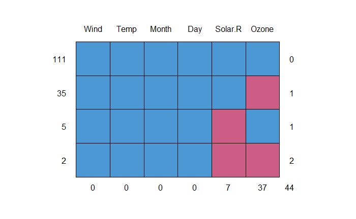

```r
library(mice)
md.pattern(airquality)
```

```r
impute<-mice(airquality,m=1,seed = 11)
data<-complete(impute)
summary(data)
```

```
     Ozone           Solar.R           Wind             Temp           Month
 Min.   :  1.00   Min.   :  7.0   Min.   : 1.700   Min.   :56.00   Min.   :5.000
 1st Qu.: 18.00   1st Qu.:115.0   1st Qu.: 7.400   1st Qu.:72.00   1st Qu.:6.000
 Median : 32.00   Median :212.0   Median : 9.700   Median :79.00   Median :7.000
 Mean   : 41.78   Mean   :186.3   Mean   : 9.958   Mean   :77.88   Mean   :6.993
 3rd Qu.: 61.00   3rd Qu.:259.0   3rd Qu.:11.500   3rd Qu.:85.00   3rd Qu.:8.000
 Max.   :168.00   Max.   :334.0   Max.   :20.700   Max.   :97.00   Max.   :9.000
      Day
 Min.   : 1.0
 1st Qu.: 8.0
 Median :16.0
 Mean   :15.8
 3rd Qu.:23.0
 Max.   :31.0
```

For simplification we remove **Day** variable and we convert the **Month** variable to factor type.

```r
data<-data[,-6]
data$Month<-as.factor(data$Month)
glimpse(data)
```

```
Observations: 153
Variables: 5
$ Ozone   <int> 41, 36, 12, 18, 32, 28, 23, 19, 8, 23, 7, 16, 11, 14, 18, 14, 34, 6, 30,…
$ Solar.R <int> 190, 118, 149, 313, 264, 213, 299, 99, 19, 194, 25, 256, 290, 274, 65, 3…
$ Wind    <dbl> 7.4, 8.0, 12.6, 11.5, 14.3, 14.9, 8.6, 13.8, 20.1, 8.6, 6.9, 9.7, 9.2, 1…
$ Temp    <int> 67, 72, 74, 62, 56, 66, 65, 59, 61, 69, 74, 69, 66, 68, 58, 64, 66, 57, …
$ Month   <fct> 5, 5, 5, 5, 5, 5, 5, 5, 5, 5, 5, 5, 5, 5, 5, 5, 5, 5, 5, 5, 5, 5, 5, 5, …
```

```r
summary(data)
```

```
     Ozone           Solar.R           Wind             Temp       Month
 Min.   :  1.00   Min.   :  7.0   Min.   : 1.700   Min.   :56.00   5:31
 1st Qu.: 18.00   1st Qu.:115.0   1st Qu.: 7.400   1st Qu.:72.00   6:30
 Median : 32.00   Median :212.0   Median : 9.700   Median :79.00   7:31
 Mean   : 41.78   Mean   :186.3   Mean   : 9.958   Mean   :77.88   8:31
 3rd Qu.: 61.00   3rd Qu.:259.0   3rd Qu.:11.500   3rd Qu.:85.00   9:30
 Max.   :168.00   Max.   :334.0   Max.   :20.700   Max.   :97.00
```